# Oman 2018 Short-chain alkane cycling taxa and Hydrogenophaga

Source file: OM18_taxa_table_analysis.Rmd

Daniel Nothaft

2020-05-26

# Setup

## Load packages

```r
library(mctoolsr) # working with taxonomic data
library(tidyverse) # working with data frames
library(knitr) # printing things nicely

# global knitting options for automatic saving of all plots as .png and .pdf. Also sets cache directory.
knitr::opts_chunk$set(
  dev = c("png", "pdf"), fig.keep = "all",
  dev.args = list(pdf = list(encoding = "WinAnsi", useDingbats = FALSE)),
  fig.path = file.path("fig_output/", paste0(gsub("\\.[Rr]md", "/", knitr::current_input()))),
  cache.path = file.path("cache/", paste0(gsub("\\.[Rr]md", "/", knitr::current_input())))
)
```

## Load in map file and otutable

```r
tax_table_fp <- 'data_output/tax_tab_DADA2_mctoolsr_OM18_Silva138_Bayes_packers.txt'
map_fp <- 'data_raw/Summary_metadata/meta_map_16S_OM18_packers.txt'
```

```r
input <- load_taxa_table(tax_table_fp, map_fp) #combine data to format for mctoolsr
```

```
## 29 samples loaded
```

# Overall trends and data curation

## look at reads per sample

Samples have more reads than controls (at minimum 5X more reads), which is good.

Show read counts

```r
sort(colSums(input$data_loaded))
```

```
##         NTC_19          NTC_9         NTC_18         NTC_15          NTC_4
##             63             78            136            154            180
##        OM18_BJ         NTC_20          NTC_1         NTC_16         NTC_17
##            376            390            542            603            725
##          NTC_7          NTC_8          NTC_5          NTC_6         NTC_14
##            888            901            903            906           1126
##         NTC_10        OM18_BD          NTC_3         NTC_12         NTC_13
##           1290           1401           1430           1730           2116
##         NTC_11        OM18_BC          NTC_2 BA1A5566_45_1J  BA1A100_10_2J
##           2222           4539           4655          25880          26893
##  BA1A100_45_2C  BA1A100_22_2D BA1A5566_22_1C BA1A5566_10_1D
##          28469          36372          37232          45728
```

Plot read counts

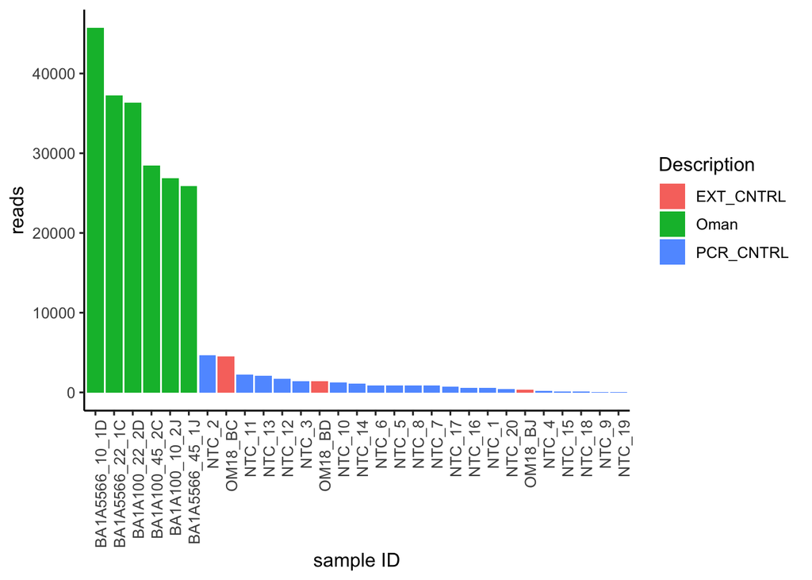

```r
# pull out metadata map
map <- input$map_loaded

# create data frame of reads
reads_per_sample_sums <- as.data.frame(colSums(input$data_loaded))

# create data frame of names of sample
reads_per_sample_names <- as.data.frame(colnames(input$data_loaded))

# combine reads with names to data frame of reads per sample
reads_per_sample <- cbind(reads_per_sample_sums, reads_per_sample_names)

# rename columns with more descriptive names
reads_per_sample <- rename(reads_per_sample, reads = "colSums(input$data_loaded)", sample_ID = "colnames(input$data_loaded)")

# add metadata
reads_per_sample <- left_join(reads_per_sample, map, by = "sample_ID") %>% select(sample_ID, reads, Description, filter_pore_size_um)

# create plot
read_tally <- reads_per_sample %>% ggplot(

  # plot data
  aes(x = reorder(sample_ID, -reads),
      y = reads,
      fill = Description)) +
  geom_bar(stat = "identity") +

  # axis styling
  scale_x_discrete(name = "sample ID") +

  # design
  theme_classic(base_size = 12) +
  theme(
    axis.text.x = element_text(angle = 90, hjust = 1))

# print plot
read_tally
```

## Filter out mitochondria, chloroplasts, eurkaryotes, and sequences not assigned taxonomy at the the domain level

```r
input_filt <- filter_taxa_from_input(input, taxa_to_remove = c("Chloroplast","Mitochondria", "Eukaryota"))
```

```
## 40 taxa removed
```

```r
input_filt <- filter_taxa_from_input(input_filt, at_spec_level = 1, taxa_to_remove = "NA")
```

```
## 3 taxa removed
```

Show read counts of filtered data

```r
sort(colSums(input_filt$data_loaded))
```

```
##         NTC_19          NTC_9         NTC_15         NTC_18          NTC_4
##             63             78            126            134            180
##        OM18_BJ         NTC_20          NTC_1         NTC_17         NTC_16
##            376            390            542            561            569
##          NTC_7          NTC_8          NTC_5          NTC_6         NTC_14
##            888            901            903            906           1077
##         NTC_10        OM18_BD          NTC_3         NTC_12         NTC_13
##           1290           1401           1430           1673           1821
##         NTC_11          NTC_2        OM18_BC BA1A5566_45_1J  BA1A100_10_2J
##           2222           4354           4494          25821          26177
##  BA1A100_45_2C  BA1A100_22_2D BA1A5566_22_1C BA1A5566_10_1D
##          28420          36297          37175          45648
```

## Focus on samples

```r
# select desired samples
Oman_samples <- input_filt %>% filter_data(filter_cat = "sample_ID", keep_vals = c( "BA1A5566_45_1J", "BA1A100_10_2J", "BA1A100_45_2C", "BA1A5566_22_1C","BA1A100_22_2D", "BA1A5566_10_1D"))
```

```
## 6 samples remaining
```

Rarefy to lowest read count among samples

```r
Oman_samples = single_rarefy(Oman_samples, min(sort(colSums(Oman_samples$data_loaded))))
```

```
## 6 samples remaining
```

```r
# extract metadata for desired samples
map_Oman_samples <- Oman_samples$map_loaded
```

# Taxonomic overview

Summarize taxonomy at species level

```r
# summarize taxonomic classification at species level
Oman_samples_sum <- summarize_taxonomy(Oman_samples, level = 7, report_higher_tax = TRUE)
```

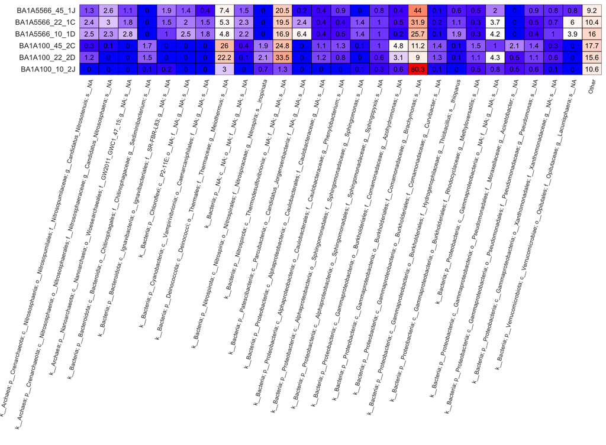

```r
Oman_samples_sum_higher_plot <- plot_ts_heatmap(Oman_samples_sum, map_Oman_samples, 0.005,  "sample_ID")

Oman_samples_sum_higher_plot +
  theme(axis.text.x = element_text(angle = 75, hjust = 1, vjust = 1, size = 7))
```

# Xanthomonadaceae

## Sort data

### list taxa of interest

```r
# input methane cycle
Xanthomonadaceae <- c("Xanthomonadaceae")
```

### filter for all Silanimonas taxa

```r
# filter for CH4-cycling taxa
Oman_samples_sum_all_Xanthomonadaceae <- filter_taxa_from_table(tax_table =  Oman_samples_sum, taxa_to_keep = Xanthomonadaceae)

# get rownames of CH4 cycle taxa data frame
tax_long <- tibble(rownames(Oman_samples_sum_all_Xanthomonadaceae))
colnames(tax_long) <- "tax_long"

# Reshaping data so it is easier to work with

# make rownames into a column
Oman_samples_sum_all_Xanthomonadaceae <- bind_cols(tax_long, Oman_samples_sum_all_Xanthomonadaceae)

# print
Oman_samples_sum_all_Xanthomonadaceae
```

| tax_long | BA1A100_10_2J | BA1A100_22_2D | BA1A100_45_2C | BA1A5566_10_1D | BA1A5566_22_1C | BA1A5566_45_1J |
| --- | --- | --- | --- | --- | --- | --- |
| k__Bacteria; p__Proteobacteria; c__Gammaproteobacteria; o__Xanthomonadales; f__Xanthomonadaceae; g__Lysobacter; s__NA | 0.000000000 | 0.001084389 | 0.001665311 | 0.0027884280 | 0.0017814957 | 0.0007358352 |
| k__Bacteria; p__Proteobacteria; c__Gammaproteobacteria; o__Xanthomonadales; f__Xanthomonadaceae; g__NA; s__NA | 0.001006932 | 0.005576856 | 0.003059525 | 0.0098369544 | 0.0070872546 | 0.0083652841 |
| k__Bacteria; p__Proteobacteria; c__Gammaproteobacteria; o__Xanthomonadales; f__Xanthomonadaceae; g__Pseudoxanthomonas; s__NA | 0.000000000 | 0.002130049 | 0.003020797 | 0.0005809225 | 0.0008520197 | 0.0007745633 |
| k__Bacteria; p__Proteobacteria; c__Gammaproteobacteria; o__Xanthomonadales; f__Xanthomonadaceae; g__Silanimonas; s__NA | 0.001432942 | 0.006467604 | 0.007513264 | 0.0000000000 | 0.0000000000 | 0.0000000000 |

### show full taxonomy of Xanthomonadaceae taxa in easily searchable format

```r
# gather data
Oman_samples_sum_all_Xanthomonadaceae_long_gathered <- Oman_samples_sum_all_Xanthomonadaceae %>%  gather(key = "sample_ID", value = "rel_abund", -tax_long)

# pretty print
Oman_samples_sum_all_Xanthomonadaceae_long_gathered %>% kable()
```

| tax_long | sample_ID | rel_abund |
| --- | --- | --- |
| k__Bacteria; p__Proteobacteria; c__Gammaproteobacteria; o__Xanthomonadales; f__Xanthomonadaceae; g__Lysobacter; s__NA | BA1A100_10_2J | 0.0000000 |
| k__Bacteria; p__Proteobacteria; c__Gammaproteobacteria; o__Xanthomonadales; f__Xanthomonadaceae; g__NA; s__NA | BA1A100_10_2J | 0.0010069 |
| k__Bacteria; p__Proteobacteria; c__Gammaproteobacteria; o__Xanthomonadales; f__Xanthomonadaceae; g__Pseudoxanthomonas; s__NA | BA1A100_10_2J | 0.0000000 |
| k__Bacteria; p__Proteobacteria; c__Gammaproteobacteria; o__Xanthomonadales; f__Xanthomonadaceae; g__Silanimonas; s__NA | BA1A100_10_2J | 0.0014329 |
| k__Bacteria; p__Proteobacteria; c__Gammaproteobacteria; o__Xanthomonadales; f__Xanthomonadaceae; g__Lysobacter; s__NA | BA1A100_22_2D | 0.0010844 |
| k__Bacteria; p__Proteobacteria; c__Gammaproteobacteria; o__Xanthomonadales; f__Xanthomonadaceae; g__NA; s__NA | BA1A100_22_2D | 0.0055769 |
| k__Bacteria; p__Proteobacteria; c__Gammaproteobacteria; o__Xanthomonadales; f__Xanthomonadaceae; g__Pseudoxanthomonas; s__NA | BA1A100_22_2D | 0.0021300 |
| k__Bacteria; p__Proteobacteria; c__Gammaproteobacteria; o__Xanthomonadales; f__Xanthomonadaceae; g__Silanimonas; s__NA | BA1A100_22_2D | 0.0064676 |
| k__Bacteria; p__Proteobacteria; c__Gammaproteobacteria; o__Xanthomonadales; f__Xanthomonadaceae; g__Lysobacter; s__NA | BA1A100_45_2C | 0.0016653 |
| k__Bacteria; p__Proteobacteria; c__Gammaproteobacteria; o__Xanthomonadales; f__Xanthomonadaceae; g__NA; s__NA | BA1A100_45_2C | 0.0030595 |
| k__Bacteria; p__Proteobacteria; c__Gammaproteobacteria; o__Xanthomonadales; f__Xanthomonadaceae; g__Pseudoxanthomonas; s__NA | BA1A100_45_2C | 0.0030208 |
| k__Bacteria; p__Proteobacteria; c__Gammaproteobacteria; o__Xanthomonadales; f__Xanthomonadaceae; g__Silanimonas; s__NA | BA1A100_45_2C | 0.0075133 |
| k__Bacteria; p__Proteobacteria; c__Gammaproteobacteria; o__Xanthomonadales; f__Xanthomonadaceae; g__Lysobacter; s__NA | BA1A5566_10_1D | 0.0027884 |
| k__Bacteria; p__Proteobacteria; c__Gammaproteobacteria; o__Xanthomonadales; f__Xanthomonadaceae; g__NA; s__NA | BA1A5566_10_1D | 0.0098370 |
| k__Bacteria; p__Proteobacteria; c__Gammaproteobacteria; o__Xanthomonadales; f__Xanthomonadaceae; g__Pseudoxanthomonas; s__NA | BA1A5566_10_1D | 0.0005809 |
| k__Bacteria; p__Proteobacteria; c__Gammaproteobacteria; o__Xanthomonadales; f__Xanthomonadaceae; g__Silanimonas; s__NA | BA1A5566_10_1D | 0.0000000 |
| k__Bacteria; p__Proteobacteria; c__Gammaproteobacteria; o__Xanthomonadales; f__Xanthomonadaceae; g__Lysobacter; s__NA | BA1A5566_22_1C | 0.0017815 |
| k__Bacteria; p__Proteobacteria; c__Gammaproteobacteria; o__Xanthomonadales; f__Xanthomonadaceae; g__NA; s__NA | BA1A5566_22_1C | 0.0070873 |
| k__Bacteria; p__Proteobacteria; c__Gammaproteobacteria; o__Xanthomonadales; f__Xanthomonadaceae; g__Pseudoxanthomonas; s__NA | BA1A5566_22_1C | 0.0008520 |
| k__Bacteria; p__Proteobacteria; c__Gammaproteobacteria; o__Xanthomonadales; f__Xanthomonadaceae; g__Silanimonas; s__NA | BA1A5566_22_1C | 0.0000000 |
| k__Bacteria; p__Proteobacteria; c__Gammaproteobacteria; o__Xanthomonadales; f__Xanthomonadaceae; g__Lysobacter; s__NA | BA1A5566_45_1J | 0.0007358 |
| k__Bacteria; p__Proteobacteria; c__Gammaproteobacteria; o__Xanthomonadales; f__Xanthomonadaceae; g__NA; s__NA | BA1A5566_45_1J | 0.0083653 |
| k__Bacteria; p__Proteobacteria; c__Gammaproteobacteria; o__Xanthomonadales; f__Xanthomonadaceae; g__Pseudoxanthomonas; s__NA | BA1A5566_45_1J | 0.0007746 |
| k__Bacteria; p__Proteobacteria; c__Gammaproteobacteria; o__Xanthomonadales; f__Xanthomonadaceae; g__Silanimonas; s__NA | BA1A5566_45_1J | 0.0000000 |

Add a shorthand name for taxa

```r
Oman_samples_sum_all_Xanthomonadaceae <- Oman_samples_sum_all_Xanthomonadaceae  %>% mutate(tax_short = case_when(
  tax_long == "k__Bacteria; p__Proteobacteria; c__Gammaproteobacteria; o__Xanthomonadales; f__Xanthomonadaceae; g__Lysobacter; s__NA" ~ "genus Lysobacter",
  tax_long == "k__Bacteria; p__Proteobacteria; c__Gammaproteobacteria; o__Xanthomonadales; f__Xanthomonadaceae; g__NA; s__NA" ~ "genus unassigned",
  tax_long == "k__Bacteria; p__Proteobacteria; c__Gammaproteobacteria; o__Xanthomonadales; f__Xanthomonadaceae; g__Pseudoxanthomonas; s__NA" ~ "genus Pseudoxanthomonas",
  tax_long == "k__Bacteria; p__Proteobacteria; c__Gammaproteobacteria; o__Xanthomonadales; f__Xanthomonadaceae; g__Silanimonas; s__NA" ~ "genus Silanimonas"
))

# put into easily searchable format
Oman_samples_sum_all_Xanthomonadaceae_gathered <- Oman_samples_sum_all_Xanthomonadaceae %>% gather(key = "sample_ID", value = "rel_abund", -tax_short, -tax_long)

# pretty print
Oman_samples_sum_all_Xanthomonadaceae_gathered %>% select(-tax_long) %>% kable()
```

| tax_short | sample_ID | rel_abund |
| --- | --- | --- |
| genus Lysobacter | BA1A100_10_2J | 0.0000000 |
| genus unassigned | BA1A100_10_2J | 0.0010069 |
| genus Pseudoxanthomonas | BA1A100_10_2J | 0.0000000 |
| genus Silanimonas | BA1A100_10_2J | 0.0014329 |
| genus Lysobacter | BA1A100_22_2D | 0.0010844 |
| genus unassigned | BA1A100_22_2D | 0.0055769 |
| genus Pseudoxanthomonas | BA1A100_22_2D | 0.0021300 |
| genus Silanimonas | BA1A100_22_2D | 0.0064676 |
| genus Lysobacter | BA1A100_45_2C | 0.0016653 |
| genus unassigned | BA1A100_45_2C | 0.0030595 |
| genus Pseudoxanthomonas | BA1A100_45_2C | 0.0030208 |
| genus Silanimonas | BA1A100_45_2C | 0.0075133 |
| genus Lysobacter | BA1A5566_10_1D | 0.0027884 |
| genus unassigned | BA1A5566_10_1D | 0.0098370 |
| genus Pseudoxanthomonas | BA1A5566_10_1D | 0.0005809 |
| genus Silanimonas | BA1A5566_10_1D | 0.0000000 |
| genus Lysobacter | BA1A5566_22_1C | 0.0017815 |
| genus unassigned | BA1A5566_22_1C | 0.0070873 |
| genus Pseudoxanthomonas | BA1A5566_22_1C | 0.0008520 |
| genus Silanimonas | BA1A5566_22_1C | 0.0000000 |
| genus Lysobacter | BA1A5566_45_1J | 0.0007358 |
| genus unassigned | BA1A5566_45_1J | 0.0083653 |
| genus Pseudoxanthomonas | BA1A5566_45_1J | 0.0007746 |
| genus Silanimonas | BA1A5566_45_1J | 0.0000000 |

Add metadata map to gathered Xanthomonadaceae taxa data frame

```r
# join meta data map to Xanthomonadaceae taxa data frame
gathered_w_map <- left_join(Oman_samples_sum_all_Xanthomonadaceae_gathered, map_Oman_samples, by = "sample_ID")
```

## Plot

### Prepare plot aesthetics

reorder factor levels so bar and legend plot in desired order

```r
gathered_w_map$tax_short <- factor(gathered_w_map$tax_short, levels = c(
  "genus unassigned",
  "genus Lysobacter",
  "genus Pseudoxanthomonas",
  "genus Silanimonas"))
```

Set fill colors for taxa

```r
# color-blind safe palette :
#F0E442 yellow
#E69F00 orange
#D55E00 red
#CC79A7 magenta
#009E73 forest/mint green
#56B4E9 light blue
#0072B2 dark blue
#999999 grey
#000000 black

fill_taxa_named_Xanthomonadaceae <- c(
  "genus Lysobacter" = "#56B4E9",
  "genus unassigned" = "#999999",
  "genus Pseudoxanthomonas" = "#D55E00",
  "genus Silanimonas" = "#000000")
```

set factor levels for wells so that they are ordered as desired on plot

```r
# gathered_w_map$well <- factor(gathered_w_map$well, levels = c("WAB103", "WAB188", "WAB104", "WAB105", "WAB55", "NSHQ04", "WAB71", "CM2A", "NSHQ14"))
```

make formatting function to convert relative abundances to percent during plotting

```r
formatter100 <- function(x){
    x*100
}
```

### Plot

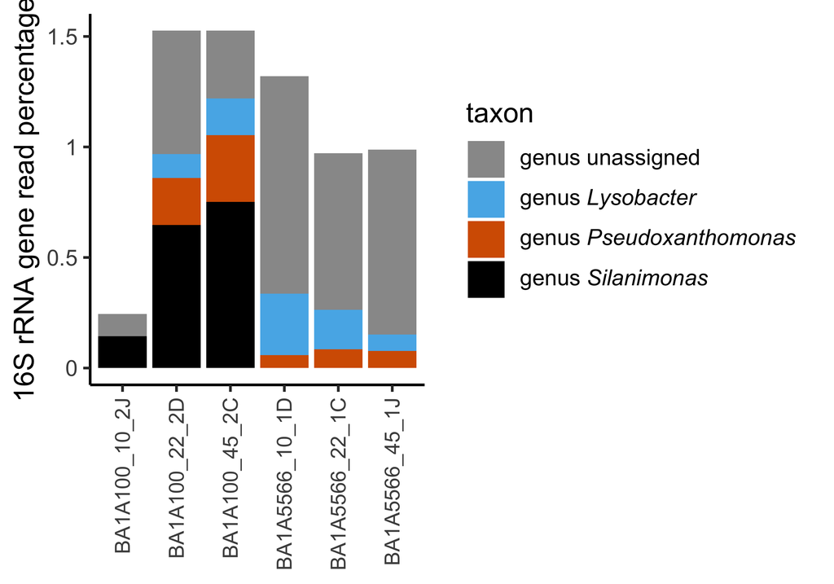

```r
# create plot
OM18_Xanthomonadaceae_bar <- gathered_w_map %>% ggplot(

  # plot data
  aes(x = sample_ID,
      y = rel_abund,
      fill = tax_short)) +
  geom_bar(stat = "identity") +

  # axis styling
  scale_y_continuous(name = "16S rRNA gene read percentage", labels = formatter100)+
  scale_x_discrete(name = NULL)+

  # symbol styling
  scale_fill_manual(name = "taxon", values = fill_taxa_named_Xanthomonadaceae, labels = unname(latex2exp::TeX(c( "genus unassigned",
  "genus \\textit{Lysobacter}",
  "genus \\textit{Pseudoxanthomonas}",
  "genus \\textit{Silanimonas}")))) +

  # design
  theme_classic(base_size = 12)+
  theme(
    axis.text.x = element_text(angle = 90, hjust = 1, vjust = 0.5, size = 9),
    legend.direction = "vertical",
    legend.text.align = 0
)

# print
OM18_Xanthomonadaceae_bar
```

# CH$_4$-cycling taxa

## Sort data

### list taxa of interest

```r
# input methane cycle
all_methane_taxa_oman <- c("Methanobacteria", "Methanomicrobia", "Methanopyrales", "Methanocellales", "Methanoplasmatales", "Methanosarcinales", "Methanomassiliicocc", "Methylococc", "Methylocystis", "Methylosinus", "Methylocella", "Methylocapsa", "Methylacidiphil", "Methylomirabilis", "ANME")
```

### filter for all CH$_4$-cycling taxa

```r
# filter for CH4-cycling taxa
Oman_samples_sum_all_methane_taxa <- filter_taxa_from_table(tax_table =  Oman_samples_sum, taxa_to_keep = all_methane_taxa_oman)

# get rownames of CH4 cycle taxa data frame
tax_long <- tibble(rownames(Oman_samples_sum_all_methane_taxa))
colnames(tax_long) <- "tax_long"

# Reshaping data so it is easier to work with

# make rownames into a column
Oman_samples_sum_all_methane_taxa <- bind_cols(tax_long, Oman_samples_sum_all_methane_taxa)

# print
Oman_samples_sum_all_methane_taxa
```

| tax_long | BA1A100_10_2J | BA1A100_22_2D | BA1A100_45_2C | BA1A5566_10_1D | BA1A5566_22_1C | BA1A5566_45_1J |
| --- | --- | --- | --- | --- | --- | --- |
| k__Archaea; p__Euryarchaeota; c__Methanobacteria; o__Methanobacteriales; f__Methanobacteriaceae; g__Methanobacterium; s__NA | 0.001471670 | 0.0003872817 | 0.000464738 | 0 | 0 | 0 |
| k__Bacteria; p__Proteobacteria; c__Gammaproteobacteria; o__Methylococcales; f__Methylococcaceae; g__Methylocaldum; s__NA | 0.000929476 | 0.0000000000 | 0.000000000 | 0 | 0 | 0 |

### show full taxonomy of CH$_4$-cycling taxa in easily searchable format

```r
# gather data
Oman_samples_sum_all_methane_taxa_long_gathered <- Oman_samples_sum_all_methane_taxa %>%  gather(key = "sample_ID", value = "rel_abund", -tax_long)

# pretty print
Oman_samples_sum_all_methane_taxa_long_gathered %>% kable()
```

| tax_long | sample_ID | rel_abund |
| --- | --- | --- |
| k__Archaea; p__Euryarchaeota; c__Methanobacteria; o__Methanobacteriales; f__Methanobacteriaceae; g__Methanobacterium; s__NA | BA1A100_10_2J | 0.0014717 |
| k__Bacteria; p__Proteobacteria; c__Gammaproteobacteria; o__Methylococcales; f__Methylococcaceae; g__Methylocaldum; s__NA | BA1A100_10_2J | 0.0009295 |
| k__Archaea; p__Euryarchaeota; c__Methanobacteria; o__Methanobacteriales; f__Methanobacteriaceae; g__Methanobacterium; s__NA | BA1A100_22_2D | 0.0003873 |
| k__Bacteria; p__Proteobacteria; c__Gammaproteobacteria; o__Methylococcales; f__Methylococcaceae; g__Methylocaldum; s__NA | BA1A100_22_2D | 0.0000000 |
| k__Archaea; p__Euryarchaeota; c__Methanobacteria; o__Methanobacteriales; f__Methanobacteriaceae; g__Methanobacterium; s__NA | BA1A100_45_2C | 0.0004647 |
| k__Bacteria; p__Proteobacteria; c__Gammaproteobacteria; o__Methylococcales; f__Methylococcaceae; g__Methylocaldum; s__NA | BA1A100_45_2C | 0.0000000 |
| k__Archaea; p__Euryarchaeota; c__Methanobacteria; o__Methanobacteriales; f__Methanobacteriaceae; g__Methanobacterium; s__NA | BA1A5566_10_1D | 0.0000000 |
| k__Bacteria; p__Proteobacteria; c__Gammaproteobacteria; o__Methylococcales; f__Methylococcaceae; g__Methylocaldum; s__NA | BA1A5566_10_1D | 0.0000000 |
| k__Archaea; p__Euryarchaeota; c__Methanobacteria; o__Methanobacteriales; f__Methanobacteriaceae; g__Methanobacterium; s__NA | BA1A5566_22_1C | 0.0000000 |
| k__Bacteria; p__Proteobacteria; c__Gammaproteobacteria; o__Methylococcales; f__Methylococcaceae; g__Methylocaldum; s__NA | BA1A5566_22_1C | 0.0000000 |
| k__Archaea; p__Euryarchaeota; c__Methanobacteria; o__Methanobacteriales; f__Methanobacteriaceae; g__Methanobacterium; s__NA | BA1A5566_45_1J | 0.0000000 |
| k__Bacteria; p__Proteobacteria; c__Gammaproteobacteria; o__Methylococcales; f__Methylococcaceae; g__Methylocaldum; s__NA | BA1A5566_45_1J | 0.0000000 |

Add a shorthand name for taxa

```r
Oman_samples_sum_all_methane_taxa <- Oman_samples_sum_all_methane_taxa  %>% mutate(tax_short = case_when(
  tax_long == "k__Archaea; p__Euryarchaeota; c__Methanobacteria; o__Methanobacteriales; f__Methanobacteriaceae; g__Methanobacterium; s__NA" ~ "genus Methanobacterium",
  tax_long == "k__Archaea; p__Halobacterota; c__ANME-1; o__ANME-1b; f__NA; g__NA; s__NA" ~ "order ANME-1b",
  tax_long == "k__Bacteria; p__Methylomirabilota; c__Methylomirabilia; o__Methylomirabilales; f__Methylomirabilaceae; g__Candidatus_Methylomirabilis; s__NA" ~ "genus Candidatus Methylomirabilis",
  tax_long == "k__Bacteria; p__Proteobacteria; c__Alphaproteobacteria; o__Rhizobiales; f__Beijerinckiaceae; g__Methylocystis; s__NA" ~ "genus Methylocystis",
  tax_long == "k__Bacteria; p__Proteobacteria; c__Gammaproteobacteria; o__Methylococcales; f__Methylococcaceae; g__Methylocaldum; s__NA" ~ "genus Methylocaldum",
  tax_long == "k__Bacteria; p__Proteobacteria; c__Gammaproteobacteria; o__Methylococcales; f__Methylococcaceae; g__Methylococcus; s__NA" ~ "genus Methylococcus",
  tax_long == "k__Bacteria; p__Proteobacteria; c__Gammaproteobacteria; o__Methylococcales; f__Methylococcaceae; g__Methyloterricola; s__NA" ~ "genus Methyloterricola"
))

# put into easily searchable format
Oman_samples_sum_all_methane_taxa_gathered <- Oman_samples_sum_all_methane_taxa %>% gather(key = "sample_ID", value = "rel_abund", -tax_short, -tax_long)

# pretty print
Oman_samples_sum_all_methane_taxa_gathered %>% select(-tax_long) %>% kable()
```

| tax_short | sample_ID | rel_abund |
| --- | --- | --- |
| genus Methanobacterium | BA1A100_10_2J | 0.0014717 |
| genus Methylocaldum | BA1A100_10_2J | 0.0009295 |
| genus Methanobacterium | BA1A100_22_2D | 0.0003873 |
| genus Methylocaldum | BA1A100_22_2D | 0.0000000 |
| genus Methanobacterium | BA1A100_45_2C | 0.0004647 |
| genus Methylocaldum | BA1A100_45_2C | 0.0000000 |
| genus Methanobacterium | BA1A5566_10_1D | 0.0000000 |
| genus Methylocaldum | BA1A5566_10_1D | 0.0000000 |
| genus Methanobacterium | BA1A5566_22_1C | 0.0000000 |
| genus Methylocaldum | BA1A5566_22_1C | 0.0000000 |
| genus Methanobacterium | BA1A5566_45_1J | 0.0000000 |
| genus Methylocaldum | BA1A5566_45_1J | 0.0000000 |

Add metadata map to gathered CH$_4$-cycling taxa data frame

```r
# join meta data map to CH4-cycling taxa data frame
gathered_w_map <- left_join(Oman_samples_sum_all_methane_taxa_gathered, map_Oman_samples, by = "sample_ID")
```

## Plot

### Prepare plot aesthetics

reorder factor levels so bar and legend plot in desired order

```r
gathered_w_map$tax_short <- factor(gathered_w_map$tax_short, levels = c(
  "genus Methylococcus",
  "genus Methylocaldum",
  "genus Methyloterricola",
  "genus Methylocystis",
  "genus Candidatus Methylomirabilis",
  "order ANME-1b",
  "genus Methanobacterium"))
```

Set fill colors for taxa

```r
# color-blind safe palette :
#F0E442 yellow
#E69F00 orange
#D55E00 red
#CC79A7 magenta
#009E73 forest/mint green
#56B4E9 light blue
#0072B2 dark blue
#999999 grey
#000000 black

fill_taxa_named <- c(
  "genus Methylococcus" = "#F0E442",
  "genus Methylocaldum" = "#E69F00",
  "genus Methyloterricola" = "#D55E00",
  "genus Methylocystis" = "#CC79A7",
  "genus Candidatus Methylomirabilis" = "#009E73",
  "order ANME-1b" = "#0072B2",
  "genus Methanobacterium" = "#000000")
```

set factor levels for wells so that they are ordered as desired on plot

```r
# gathered_w_map$well <- factor(gathered_w_map$well, levels = c("WAB103", "WAB188", "WAB104", "WAB105", "WAB55", "NSHQ04", "WAB71", "CM2A", "NSHQ14"))
```

### Plot

[figure not shown]

```r
# create plot
OM18_CH4_taxa_bar <- gathered_w_map %>% ggplot(

  # plot data
  aes(x = sample_ID,
      y = rel_abund,
      fill = tax_short)) +
  geom_bar(stat = "identity") +

  # axis styling
  scale_y_continuous(name = "16S rRNA gene read percentage", labels = formatter100)+
  scale_x_discrete(name = NULL)+

  # symbol styling
  scale_fill_manual(name = "taxon", values = fill_taxa_named, labels = unname(latex2exp::TeX(c("genus \\textit{Methylococcus}",
  "genus \\textit{Methylocaldum}",
  "genus \\textit{Methyloterricola}",
  "genus \\textit{Methylocystis}",
  "genus \\textit{Candidatus Methylomirabilis}",
  "order ANME-1b",
  "genus \\textit{Methanobacterium}")))) +

  # design
  theme_classic(base_size = 12)+
  theme(
    axis.text.x = element_text(angle = 90, hjust = 1, vjust = 0.5, size = 9),
    legend.direction = "vertical",
    legend.text.align = 0
)

# print
OM18_CH4_taxa_bar
```

# Hydrogenophaga

## Sort data

### list taxa of interest

```r
# input methane cycle
all_Hydrogenophaga_oman <- c("Hydrogenophaga")
```

### filter for all Hydrogenophaga

```r
# filter for Hydrogenophaga
Oman_samples_sum_all_Hydrogenophaga <- filter_taxa_from_table(tax_table =  Oman_samples_sum, taxa_to_keep = all_Hydrogenophaga_oman)

# get rownames of Hydrogenophaga data frame
tax_long <- tibble(rownames(Oman_samples_sum_all_Hydrogenophaga))
colnames(tax_long) <- "tax_long"

# Reshaping data so it is easier to work with

# make rownames into a column
Oman_samples_sum_all_Hydrogenophaga <- bind_cols(tax_long, Oman_samples_sum_all_Hydrogenophaga)

# print
Oman_samples_sum_all_Hydrogenophaga
```

| tax_long | BA1A100_10_2J | BA1A100_22_2D | BA1A100_45_2C | BA1A5566_10_1D | BA1A5566_22_1C | BA1A5566_45_1J |
| --- | --- | --- | --- | --- | --- | --- |
| k__Bacteria; p__Proteobacteria; c__Gammaproteobacteria; o__Burkholderiales; f__Comamonadaceae; g__Hydrogenophaga; s__NA | 0 | 0.002401146 | 0.003098253 | 0 | 0 | 0 |

### show full taxonomy of Hydrogenophaga in easily searchable format

```r
# gather data
Oman_samples_sum_all_Hydrogenophaga_gathered <- Oman_samples_sum_all_Hydrogenophaga %>%  gather(key = "sample_ID", value = "rel_abund", -tax_long)

# pretty print
Oman_samples_sum_all_Hydrogenophaga_gathered %>% kable()
```

| tax_long | sample_ID | rel_abund |
| --- | --- | --- |
| k__Bacteria; p__Proteobacteria; c__Gammaproteobacteria; o__Burkholderiales; f__Comamonadaceae; g__Hydrogenophaga; s__NA | BA1A100_10_2J | 0.0000000 |
| k__Bacteria; p__Proteobacteria; c__Gammaproteobacteria; o__Burkholderiales; f__Comamonadaceae; g__Hydrogenophaga; s__NA | BA1A100_22_2D | 0.0024011 |
| k__Bacteria; p__Proteobacteria; c__Gammaproteobacteria; o__Burkholderiales; f__Comamonadaceae; g__Hydrogenophaga; s__NA | BA1A100_45_2C | 0.0030983 |
| k__Bacteria; p__Proteobacteria; c__Gammaproteobacteria; o__Burkholderiales; f__Comamonadaceae; g__Hydrogenophaga; s__NA | BA1A5566_10_1D | 0.0000000 |
| k__Bacteria; p__Proteobacteria; c__Gammaproteobacteria; o__Burkholderiales; f__Comamonadaceae; g__Hydrogenophaga; s__NA | BA1A5566_22_1C | 0.0000000 |
| k__Bacteria; p__Proteobacteria; c__Gammaproteobacteria; o__Burkholderiales; f__Comamonadaceae; g__Hydrogenophaga; s__NA | BA1A5566_45_1J | 0.0000000 |

group taxa at genus level (Hydrogenophaga)

```r
# add grouped taxa name
Oman_samples_sum_all_Hydrogenophaga <- Oman_samples_sum_all_Hydrogenophaga  %>% mutate(tax_group = case_when(
  str_detect(tax_long, "Hydrogenophaga") == TRUE ~ "genus Hydrogenophaga"
))

# sum grouped taxa relative abundances
Oman_samples_sum_all_Hydrogenophaga_grouped <- plyr::ddply(Oman_samples_sum_all_Hydrogenophaga, plyr::.(tax_group), plyr::numcolwise(sum))

# print
Oman_samples_sum_all_Hydrogenophaga_grouped
```

| tax_group | BA1A100_10_2J | BA1A100_22_2D | BA1A100_45_2C | BA1A5566_10_1D | BA1A5566_22_1C | BA1A5566_45_1J |
| --- | --- | --- | --- | --- | --- | --- |
| genus Hydrogenophaga | 0 | 0.002401146 | 0.003098253 | 0 | 0 | 0 |

### show Hydrogenophaga genus abundances in easily searchable format

```r
# gather genus-level Hydrogenophaga data frame
Oman_samples_sum_all_Hydrogenophaga_grouped_gathered <- Oman_samples_sum_all_Hydrogenophaga_grouped %>%  gather(key = "sample_ID", value = "rel_abund", -tax_group)

# pretty print
Oman_samples_sum_all_Hydrogenophaga_grouped_gathered %>% kable()
```

| tax_group | sample_ID | rel_abund |
| --- | --- | --- |
| genus Hydrogenophaga | BA1A100_10_2J | 0.0000000 |
| genus Hydrogenophaga | BA1A100_22_2D | 0.0024011 |
| genus Hydrogenophaga | BA1A100_45_2C | 0.0030983 |
| genus Hydrogenophaga | BA1A5566_10_1D | 0.0000000 |
| genus Hydrogenophaga | BA1A5566_22_1C | 0.0000000 |
| genus Hydrogenophaga | BA1A5566_45_1J | 0.0000000 |

## Plot

### Prepare plot aesthetics

Add metadata

```r
# add metadata
gathered_grouped_w_map_Hydrogenophaga <- left_join(Oman_samples_sum_all_Hydrogenophaga_grouped_gathered, map_Oman_samples, by = "sample_ID")

# print
gathered_grouped_w_map_Hydrogenophaga
```

| tax_group | sample_ID | rel_abund | BarcodeSequence | LinkerPrimerSequence | Description | filter_type | filter_pore_size_um | extractor | well |
| --- | --- | --- | --- | --- | --- | --- | --- | --- | --- |
| genus Hydrogenophaga | BA1A100_10_2J | 0.000000000 | AGTATATGTTTC | AA | Oman | inline | 10 | J | BA1A100 |
| genus Hydrogenophaga | BA1A100_22_2D | 0.002401146 | GGCTCGTCGGAG | AA | Oman | inline | 22 | D | BA1A100 |
| genus Hydrogenophaga | BA1A100_45_2C | 0.003098253 | GACATCTGACAC | AA | Oman | inline | 45 | C | BA1A100 |
| genus Hydrogenophaga | BA1A5566_10_1D | 0.000000000 | ATGTTAGGGAAT | AA | Oman | inline | 10 | D | BA1A5566 |
| genus Hydrogenophaga | BA1A5566_22_1C | 0.000000000 | AAGTGGCTATCC | AA | Oman | inline | 22 | C | BA1A5566 |
| genus Hydrogenophaga | BA1A5566_45_1J | 0.000000000 | GTCGTTACCCGC | AA | Oman | inline | 45 | J | BA1A5566 |

reorder factor levels so bar and legend plot in desired order

```r
# # reorder factor levels
# gathered_grouped_w_map_Hydrogenophaga$well <- factor(gathered_grouped_w_map_Hydrogenophaga$well, levels = c("WAB103", "WAB188", "WAB104", "WAB105", "WAB55", "NSHQ04", "WAB71", "CM2A", "NSHQ14"))
```

### Plot

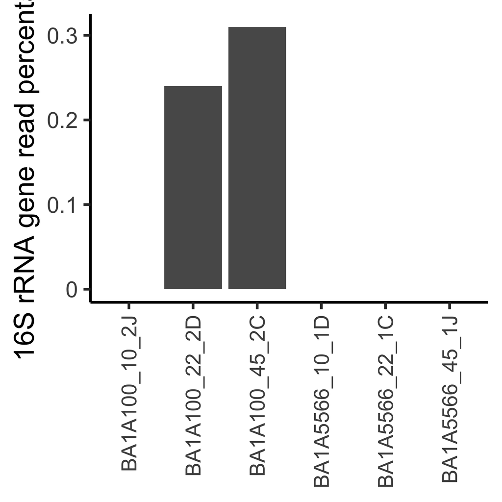

```r
# create plot
OM18_Hydrogenophaga_bar <- gathered_grouped_w_map_Hydrogenophaga %>% ggplot(

  # plot data
  aes(x = sample_ID,
      y = rel_abund)) +
  geom_bar(stat = "identity") +

  # axis styling
  scale_y_continuous(name = "16S rRNA gene read percentage", labels = formatter100)+
  scale_x_discrete(name = NULL)+

  # design
  theme_classic(base_size = 12)+
  theme(
    axis.text.x = element_text(angle = 90, hjust = 1, vjust = 0.5, size = 9),
    legend.direction = "vertical",
    legend.text.align = 0
)

# print
OM18_Hydrogenophaga_bar
```

# $\text{C}_{2+}$ Short-Chain Alkane (SCA)-consuming taxa

## Sort Data

### list taxa of interest

```r
# input SCA-consuming taxa from Singh et al. (2017), Laso-Pérez et al. (2019), and Shennan et al. (2006)

all_SCA_taxa_oman <- c("BuS5", "Syntrophoarchaeum", "HotSeep-1", "Argoarchaeum", "ethanivorans", "Methanoliparia", "GoM", "Actinomyces", "Arthrobacter", "Brevibacterium", "Corynebacterium", "Gordonia", "Mycobacterium", "Nocardia", "Nocardiodes", "Rhodococcus", "Acinetobacter", "cepacia", "Pseudomonas", "Ralstonia")
```

Looking at a broader taxonomic level

Regarding symbiotic SRB, I was interested if there was anything related to the Desulfosarcina/Desulfococcus (DSS) cluster within Deltaproteobacteria because this is the clade within which strain BuS5 (Laso-Pérez 2016) resides, but we see no evidence of closely related organisms in this Oman dataset.

```r
# input SCA-consuming
all_SCA_taxa_oman_broader <- c("Desulfobacteriaceae", "Desulfococcus", "Desulfosarcina", "Desulfobacterales", "Deltaproteobacteria", "Euryarchaeota")
```

### filter for all SCA-consuming taxa

Here, we see that there are no species-level identification of $\text{C}_{2+}$ short-chain alkane-oxidizing microbes. Many species in these genera do not perform short-chain alkane oxidation. Therefore, there is no conclusive detection of alkane-oxidizing microbes in this dataset. I still go on to plot these, for reference.

```r
# select SCA-consuming taxa
Oman_samples_sum_all_SCA_taxa <- filter_taxa_from_table(tax_table =  Oman_samples_sum, taxa_to_keep = all_SCA_taxa_oman )

# print SCA-consuming taxa
Oman_samples_sum_all_SCA_taxa
```

|  | BA1A100_10_2J | BA1A100_22_2D | BA1A100_45_2C | BA1A5566_10_1D | BA1A5566_22_1C | BA1A5566_45_1J |
| --- | --- | --- | --- | --- | --- | --- |
| k__Bacteria; p__Proteobacteria; c__Gammaproteobacteria; o__Pseudomonadales; f__Moraxellaceae; g__Acinetobacter; s__NA | 0.005460672 | 0.005421943 | 0.02083575 | 0.000000000 | 7.745633e-05 | 0.000000000 |
| k__Bacteria; p__Proteobacteria; c__Gammaproteobacteria; o__Pseudomonadales; f__Pseudomonadaceae; g__Pseudomonas; s__NA | 0.006080322 | 0.011269897 | 0.01405832 | 0.003950273 | 4.802293e-03 | 0.008713838 |

broader taxonomic level

```r
# select SCA-consuming taxa
Oman_samples_sum_all_SCA_taxa_broader <- filter_taxa_from_table(tax_table =  Oman_samples_sum, taxa_to_keep = all_SCA_taxa_oman_broader)

# print SCA-consuming taxa
Oman_samples_sum_all_SCA_taxa_broader
```

|  | BA1A100_10_2J | BA1A100_22_2D | BA1A100_45_2C | BA1A5566_10_1D | BA1A5566_22_1C | BA1A5566_45_1J |
| --- | --- | --- | --- | --- | --- | --- |
| k__Archaea; p__Euryarchaeota; c__Methanobacteria; o__Methanobacteriales; f__Methanobacteriaceae; g__Methanobacterium; s__NA | 0.00147167 | 0.0003872817 | 0.000464738 | 0 | 0 | 0 |

remove Methanobacterium, which is not a SCA oxidizer

```r
Oman_samples_sum_all_SCA_taxa_broader <- filter_taxa_from_table(tax_table =  Oman_samples_sum_all_SCA_taxa_broader, taxa_to_remove = "Methanobacterium" )
```

Reshaping data so it is easier to work with

```r
# get taxa names
tax_long_SCA <- tibble(rownames(Oman_samples_sum_all_SCA_taxa))
colnames(tax_long_SCA) <- "tax_long"

# make rownames into a column
Oman_samples_sum_all_SCA_taxa <- bind_cols(Oman_samples_sum_all_SCA_taxa, tax_long_SCA)

#print
Oman_samples_sum_all_SCA_taxa
```

| BA1A100_10_2J | BA1A100_22_2D | BA1A100_45_2C | BA1A5566_10_1D | BA1A5566_22_1C | BA1A5566_45_1J | tax_long |
| --- | --- | --- | --- | --- | --- | --- |
| 0.005460672 | 0.005421943 | 0.02083575 | 0.000000000 | 7.745633e-05 | 0.000000000 | k__Bacteria; p__Proteobacteria; c__Gammaproteobacteria; o__Pseudomonadales; f__Moraxellaceae; g__Acinetobacter; s__NA |
| 0.006080322 | 0.011269897 | 0.01405832 | 0.003950273 | 4.802293e-03 | 0.008713838 | k__Bacteria; p__Proteobacteria; c__Gammaproteobacteria; o__Pseudomonadales; f__Pseudomonadaceae; g__Pseudomonas; s__NA |

```r
# get taxa names
tax_long_SCA_broader <- tibble(rownames(Oman_samples_sum_all_SCA_taxa_broader))
colnames(tax_long_SCA_broader) <- "tax_long"

# make rownames into a column
Oman_samples_sum_all_SCA_taxa_broader <- bind_cols(Oman_samples_sum_all_SCA_taxa_broader, tax_long_SCA_broader)

#print
Oman_samples_sum_all_SCA_taxa_broader
```

| BA1A100_10_2J | BA1A100_22_2D | BA1A100_45_2C | BA1A5566_10_1D | BA1A5566_22_1C | BA1A5566_45_1J | tax_long |
| --- | --- | --- | --- | --- | --- | --- |

### show full taxonomy of SCA cycling taxa in easily searchable format

```r
# gather data
Oman_samples_sum_all_SCA_taxa_long_gathered <- Oman_samples_sum_all_SCA_taxa %>%  gather(key = "sample_ID", value = "rel_abund", -tax_long)

# pretty print
Oman_samples_sum_all_SCA_taxa_long_gathered %>% kable()
```

| tax_long | sample_ID | rel_abund |
| --- | --- | --- |
| k__Bacteria; p__Proteobacteria; c__Gammaproteobacteria; o__Pseudomonadales; f__Moraxellaceae; g__Acinetobacter; s__NA | BA1A100_10_2J | 0.0054607 |
| k__Bacteria; p__Proteobacteria; c__Gammaproteobacteria; o__Pseudomonadales; f__Pseudomonadaceae; g__Pseudomonas; s__NA | BA1A100_10_2J | 0.0060803 |
| k__Bacteria; p__Proteobacteria; c__Gammaproteobacteria; o__Pseudomonadales; f__Moraxellaceae; g__Acinetobacter; s__NA | BA1A100_22_2D | 0.0054219 |
| k__Bacteria; p__Proteobacteria; c__Gammaproteobacteria; o__Pseudomonadales; f__Pseudomonadaceae; g__Pseudomonas; s__NA | BA1A100_22_2D | 0.0112699 |
| k__Bacteria; p__Proteobacteria; c__Gammaproteobacteria; o__Pseudomonadales; f__Moraxellaceae; g__Acinetobacter; s__NA | BA1A100_45_2C | 0.0208358 |
| k__Bacteria; p__Proteobacteria; c__Gammaproteobacteria; o__Pseudomonadales; f__Pseudomonadaceae; g__Pseudomonas; s__NA | BA1A100_45_2C | 0.0140583 |
| k__Bacteria; p__Proteobacteria; c__Gammaproteobacteria; o__Pseudomonadales; f__Moraxellaceae; g__Acinetobacter; s__NA | BA1A5566_10_1D | 0.0000000 |
| k__Bacteria; p__Proteobacteria; c__Gammaproteobacteria; o__Pseudomonadales; f__Pseudomonadaceae; g__Pseudomonas; s__NA | BA1A5566_10_1D | 0.0039503 |
| k__Bacteria; p__Proteobacteria; c__Gammaproteobacteria; o__Pseudomonadales; f__Moraxellaceae; g__Acinetobacter; s__NA | BA1A5566_22_1C | 0.0000775 |
| k__Bacteria; p__Proteobacteria; c__Gammaproteobacteria; o__Pseudomonadales; f__Pseudomonadaceae; g__Pseudomonas; s__NA | BA1A5566_22_1C | 0.0048023 |
| k__Bacteria; p__Proteobacteria; c__Gammaproteobacteria; o__Pseudomonadales; f__Moraxellaceae; g__Acinetobacter; s__NA | BA1A5566_45_1J | 0.0000000 |
| k__Bacteria; p__Proteobacteria; c__Gammaproteobacteria; o__Pseudomonadales; f__Pseudomonadaceae; g__Pseudomonas; s__NA | BA1A5566_45_1J | 0.0087138 |

Add a shorthand name for SCA taxa

```r
Oman_samples_sum_all_SCA_taxa <- Oman_samples_sum_all_SCA_taxa  %>% mutate(tax_short = case_when(
  tax_long == "k__Bacteria; p__Actinobacteriota; c__Actinobacteria; o__Corynebacteriales; f__Corynebacteriaceae; g__Corynebacterium; s__NA" ~ "genus Corynebacterium",
  tax_long == "k__Bacteria; p__Actinobacteriota; c__Actinobacteria; o__Corynebacteriales; f__Nocardiaceae; g__Nocardia; s__NA" ~ "genus Nocardia",
  tax_long == "k__Bacteria; p__Proteobacteria; c__Gammaproteobacteria; o__Pseudomonadales; f__Moraxellaceae; g__Acinetobacter; s__NA" ~ "genus Acinetobacter",
  tax_long == "k__Bacteria; p__Proteobacteria; c__Gammaproteobacteria; o__Pseudomonadales; f__Pseudomonadaceae; g__Pseudomonas; s__NA" ~ "genus Pseudomonas"
))

# put into easily searchable format
Oman_samples_sum_all_SCA_taxa_gathered <- Oman_samples_sum_all_SCA_taxa %>% gather(key = "sample_ID", value = "rel_abund", -tax_short, -tax_long)

# pretty print
Oman_samples_sum_all_SCA_taxa_gathered %>% select(-tax_long) %>% kable()
```

| tax_short | sample_ID | rel_abund |
| --- | --- | --- |
| genus Acinetobacter | BA1A100_10_2J | 0.0054607 |
| genus Pseudomonas | BA1A100_10_2J | 0.0060803 |
| genus Acinetobacter | BA1A100_22_2D | 0.0054219 |
| genus Pseudomonas | BA1A100_22_2D | 0.0112699 |
| genus Acinetobacter | BA1A100_45_2C | 0.0208358 |
| genus Pseudomonas | BA1A100_45_2C | 0.0140583 |
| genus Acinetobacter | BA1A5566_10_1D | 0.0000000 |
| genus Pseudomonas | BA1A5566_10_1D | 0.0039503 |
| genus Acinetobacter | BA1A5566_22_1C | 0.0000775 |
| genus Pseudomonas | BA1A5566_22_1C | 0.0048023 |
| genus Acinetobacter | BA1A5566_45_1J | 0.0000000 |
| genus Pseudomonas | BA1A5566_45_1J | 0.0087138 |

### Show grouped taxonomy of SCA-cycling taxa in easily searchable format

```r
gathered_w_map_SCA <- left_join(Oman_samples_sum_all_SCA_taxa_gathered, map_Oman_samples, by = "sample_ID")
#999999
gathered_w_map_SCA
```

| tax_long | tax_short | sample_ID | rel_abund | BarcodeSequence | LinkerPrimerSequence | Description | filter_type | filter_pore_size_um | extractor | well |
| --- | --- | --- | --- | --- | --- | --- | --- | --- | --- | --- |
| k__Bacteria; p__Proteobacteria; c__Gammaproteobacteria; o__Pseudomonadales; f__Moraxellaceae; g__Acinetobacter; s__NA | genus Acinetobacter | BA1A100_10_2J | 5.460672e-03 | AGTATATGTTTC | AA | Oman | inline | 10 | J | BA1A100 |
| k__Bacteria; p__Proteobacteria; c__Gammaproteobacteria; o__Pseudomonadales; f__Pseudomonadaceae; g__Pseudomonas; s__NA | genus Pseudomonas | BA1A100_10_2J | 6.080322e-03 | AGTATATGTTTC | AA | Oman | inline | 10 | J | BA1A100 |
| k__Bacteria; p__Proteobacteria; c__Gammaproteobacteria; o__Pseudomonadales; f__Moraxellaceae; g__Acinetobacter; s__NA | genus Acinetobacter | BA1A100_22_2D | 5.421943e-03 | GGCTCGTCGGAG | AA | Oman | inline | 22 | D | BA1A100 |
| k__Bacteria; p__Proteobacteria; c__Gammaproteobacteria; o__Pseudomonadales; f__Pseudomonadaceae; g__Pseudomonas; s__NA | genus Pseudomonas | BA1A100_22_2D | 1.126990e-02 | GGCTCGTCGGAG | AA | Oman | inline | 22 | D | BA1A100 |
| k__Bacteria; p__Proteobacteria; c__Gammaproteobacteria; o__Pseudomonadales; f__Moraxellaceae; g__Acinetobacter; s__NA | genus Acinetobacter | BA1A100_45_2C | 2.083575e-02 | GACATCTGACAC | AA | Oman | inline | 45 | C | BA1A100 |
| k__Bacteria; p__Proteobacteria; c__Gammaproteobacteria; o__Pseudomonadales; f__Pseudomonadaceae; g__Pseudomonas; s__NA | genus Pseudomonas | BA1A100_45_2C | 1.405832e-02 | GACATCTGACAC | AA | Oman | inline | 45 | C | BA1A100 |
| k__Bacteria; p__Proteobacteria; c__Gammaproteobacteria; o__Pseudomonadales; f__Moraxellaceae; g__Acinetobacter; s__NA | genus Acinetobacter | BA1A5566_10_1D | 0.000000e+00 | ATGTTAGGGAAT | AA | Oman | inline | 10 | D | BA1A5566 |
| k__Bacteria; p__Proteobacteria; c__Gammaproteobacteria; o__Pseudomonadales; f__Pseudomonadaceae; g__Pseudomonas; s__NA | genus Pseudomonas | BA1A5566_10_1D | 3.950273e-03 | ATGTTAGGGAAT | AA | Oman | inline | 10 | D | BA1A5566 |
| k__Bacteria; p__Proteobacteria; c__Gammaproteobacteria; o__Pseudomonadales; f__Moraxellaceae; g__Acinetobacter; s__NA | genus Acinetobacter | BA1A5566_22_1C | 7.745633e-05 | AAGTGGCTATCC | AA | Oman | inline | 22 | C | BA1A5566 |
| k__Bacteria; p__Proteobacteria; c__Gammaproteobacteria; o__Pseudomonadales; f__Pseudomonadaceae; g__Pseudomonas; s__NA | genus Pseudomonas | BA1A5566_22_1C | 4.802293e-03 | AAGTGGCTATCC | AA | Oman | inline | 22 | C | BA1A5566 |

[output cut: 2 more lines]

## Plot

### Prepare plot aesthetics

Get some plot aesthetics ready

set color blind-safe palette

```r
cbPalette <- c("#999999", "#E69F00", "#56B4E9", "#009E73", "#F0E442", "#0072B2", "#D55E00", "#CC79A7")
```

add metadata to SCA taxa

```r
# gathered_w_map_SCA$well <- factor(gathered_w_map_SCA$well, levels = c("WAB103", "WAB188", "WAB104", "WAB105", "WAB55", "NSHQ04", "WAB71", "CM2A", "NSHQ14"))
```

### Plot

[figure not shown]

```r
# create plot
OM18_SCA_taxa_bar <- gathered_w_map_SCA %>% ggplot(

  # plot data
  aes(x = sample_ID,
      y = rel_abund,
      fill = tax_short)) +
  geom_bar(stat = "identity") +

  # axis styling
  scale_y_continuous(name = "16S rRNA gene read percentage", labels = formatter100)+
  scale_x_discrete(name = NULL)+

  # symbol styling
  scale_fill_manual(name = "taxon", values = cbPalette, labels = unname(latex2exp::TeX(c("genus \\textit{Acinetobacter}",
  "genus \\textit{Corynebacterium}",
  "genus \\textit{Nocardia}",
  "genus \\textit{Pseudonomas}")))) +

  # design
  theme_classic(base_size = 12)+
  theme(
    axis.text.x = element_text(angle = 90, hjust = 1, vjust = 0.5, size = 9),
    legend.direction = "vertical",
    legend.text.align = 0
)

# print
OM18_SCA_taxa_bar
```